# Analyse RNA_SEQ

## Contrôle qualité des données

Une première analyse de la qualité des données de séquençage, réalisée avec l’outil fastqc (v0.11.7) a permis d’obtenir les statistiques suivantes avec les reads fowards de l’échantillon SA1 comme exemple :

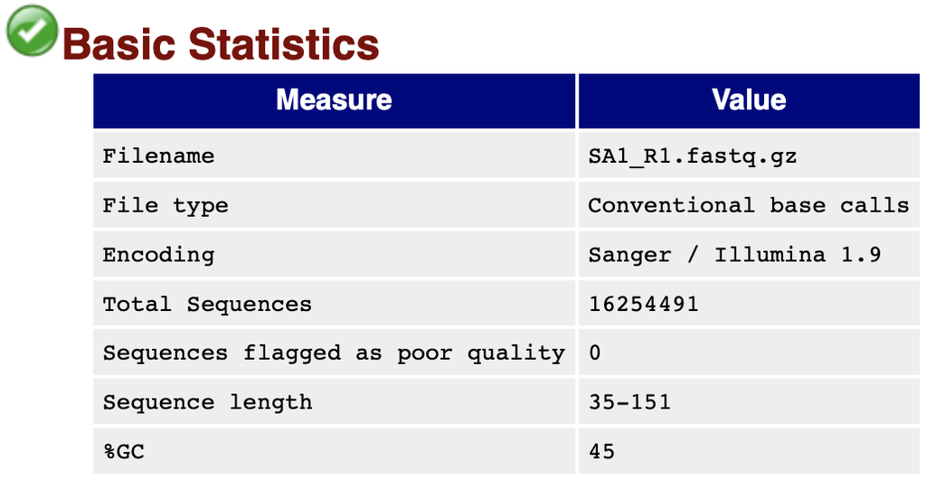

```bash
fastqc Samples/* -o fastqc_raw/
```

Comme on peut le voir sur le graphique ci-dessous, la qualité moyenne des reads est très bonne, le score Phred obtenue pour chaque base ne déscendant pas en dessous de 28, score minimal pour qu’une base soit jugée comme étant très bien prédite.

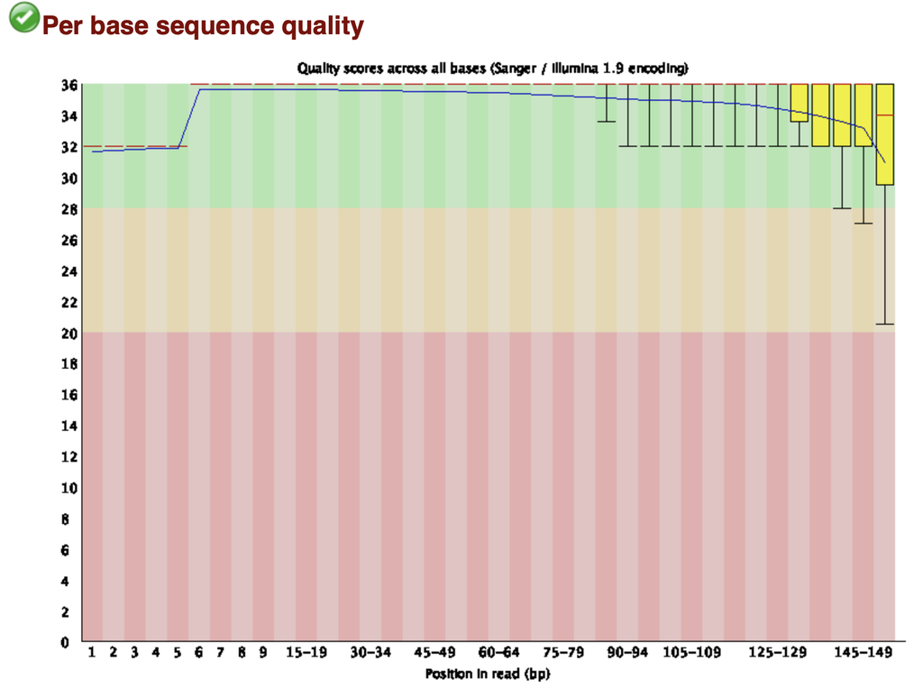

Cependant, le logiciel nous indique la présence d’adaptateurs en fin de séquences, comme le montre ce graphique:

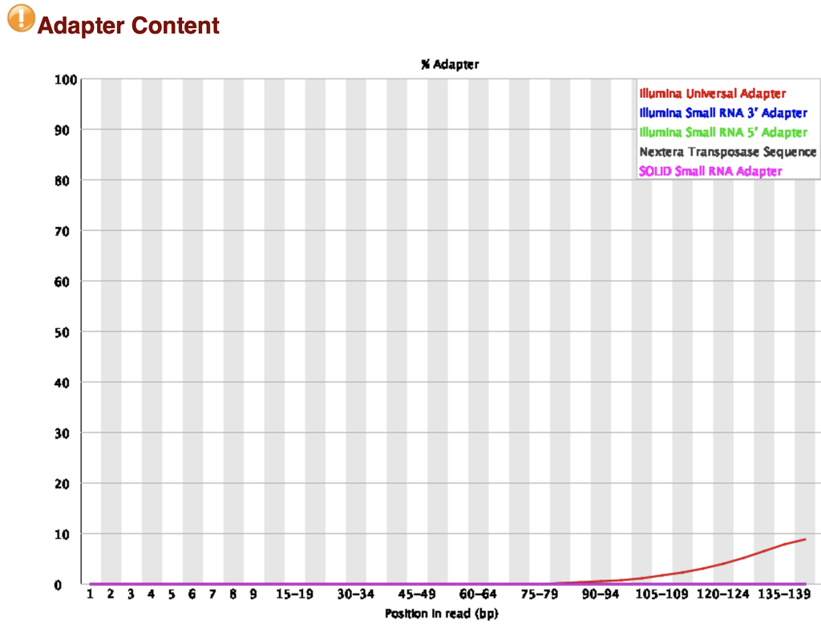

De plus, des bases sont sureprésentées en 5’, ceci étant dû aux primers qui ont pu être séquencés pour certains reads, lors de la première analyse de contrôle qualité, il a été décidé de ne pas supprimer ces premières bases afin de voir si cela gêné pour l’alignement des reads.

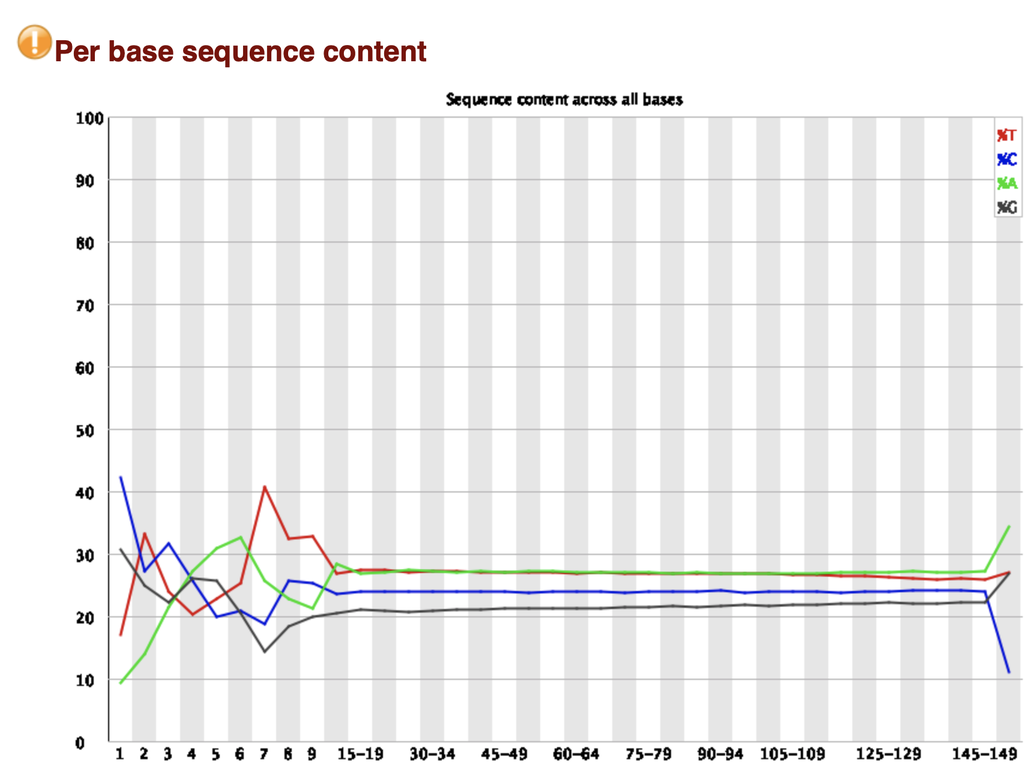

```bash
bbduk.sh in1=$R1 in2=$R2 out1=Data/Trimming/$(basename "$R1" .fastq.gz).trim.fastq out2=Data/Trimming/$(basename "$R2" .fastq.gz).trim.fastq \
    ref=/Users/vindarbo/happy_bin/bbmap/resources/adapters.fa \
    minlen=25 ktrim=l k=22 qtrim=rl trimq=10 hdist=1 tpe tbo
```

On peut voir qu’après le contrôle qualité des données, les adaptateurs ont bien été supprimés au sein des séquences:

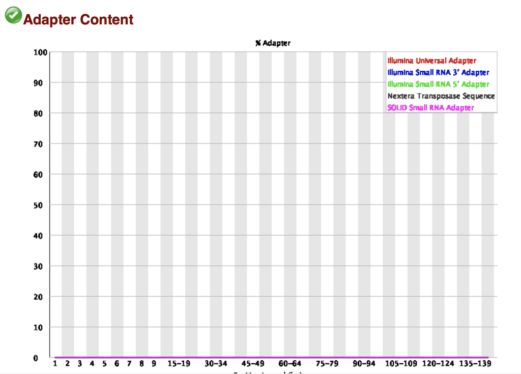

De plus, le nombre très élevée de séquences conservés après le trimming confirme la bonne qualité des données:

```
## # A tibble: 7 x 6
##   Echantillon    Avant    Apres    X. Alignement_Araport11 Alignement_TAIR…
##   <fct>          <int>    <int> <dbl>                <dbl>            <dbl>
## 1 SA1         32508982 32464906  99.9                 96.1             98.7
## 2 SA2         27096918 27059996  99.9                 96.5             99.0
## 3 SA3         29836256 29795954  99.9                 96.3             98.9
## 4 SA4         38265810 38172052  99.8                 95.9             98.9
## 5 SA5         24136782 24103590  99.9                 95.8             98.9
## 6 SA6         31164210 31102938  99.8                 96.1             99.0
## 7 SA7         37149996 37063872  99.8                 95.8             98.8
```

## Alignement des séquences